# Loan Data from Prosper

## Preliminary Wrangling

> This data set contains 113,937 loans with 81 variables on each loan, including loan amount, borrower rate (or interest rate), current loan status, borrower income, and many others.

```python
# import all packages and set plots to be embedded inline
import numpy as np
import pandas as pd
import matplotlib.pyplot as plt
import seaborn as sb

%matplotlib inline
```

```python
# Read the Data
df=pd.read_csv('prosperLoanData.csv')
df.head()
```

|  | ListingKey | ListingNumber | ListingCreationDate | CreditGrade | Term | LoanStatus | ClosedDate | BorrowerAPR | BorrowerRate | LenderYield | ... | LP_ServiceFees | LP_CollectionFees | LP_GrossPrincipalLoss | LP_NetPrincipalLoss | LP_NonPrincipalRecoverypayments | PercentFunded | Recommendations | InvestmentFromFriendsCount | InvestmentFromFriendsAmount | Investors |
| --- | --- | --- | --- | --- | --- | --- | --- | --- | --- | --- | --- | --- | --- | --- | --- | --- | --- | --- | --- | --- | --- |
| 0 | 1021339766868145413AB3B | 193129 | 2007-08-26 19:09:29.263000000 | C | 36 | Completed | 2009-08-14 00:00:00 | 0.16516 | 0.1580 | 0.1380 | ... | -133.18 | 0.0 | 0.0 | 0.0 | 0.0 | 1.0 | 0 | 0 | 0.0 | 258 |
| 1 | 10273602499503308B223C1 | 1209647 | 2014-02-27 08:28:07.900000000 | NaN | 36 | Current | NaN | 0.12016 | 0.0920 | 0.0820 | ... | 0.00 | 0.0 | 0.0 | 0.0 | 0.0 | 1.0 | 0 | 0 | 0.0 | 1 |
| 2 | 0EE9337825851032864889A | 81716 | 2007-01-05 15:00:47.090000000 | HR | 36 | Completed | 2009-12-17 00:00:00 | 0.28269 | 0.2750 | 0.2400 | ... | -24.20 | 0.0 | 0.0 | 0.0 | 0.0 | 1.0 | 0 | 0 | 0.0 | 41 |
| 3 | 0EF5356002482715299901A | 658116 | 2012-10-22 11:02:35.010000000 | NaN | 36 | Current | NaN | 0.12528 | 0.0974 | 0.0874 | ... | -108.01 | 0.0 | 0.0 | 0.0 | 0.0 | 1.0 | 0 | 0 | 0.0 | 158 |
| 4 | 0F023589499656230C5E3E2 | 909464 | 2013-09-14 18:38:39.097000000 | NaN | 36 | Current | NaN | 0.24614 | 0.2085 | 0.1985 | ... | -60.27 | 0.0 | 0.0 | 0.0 | 0.0 | 1.0 | 0 | 0 | 0.0 | 20 |

5 rows × 81 columns

## Exploring the Data

```python
# the structure of data (number of columns and rows)
df.shape
```

```
(113937, 81)
```

### Check for columns names , data types and NULL values

```python
df.info()
```

```
<class 'pandas.core.frame.DataFrame'>
RangeIndex: 113937 entries, 0 to 113936
Data columns (total 81 columns):
 #   Column                               Non-Null Count   Dtype
---  ------                               --------------   -----
 0   ListingKey                           113937 non-null  object
 1   ListingNumber                        113937 non-null  int64
 2   ListingCreationDate                  113937 non-null  object
 3   CreditGrade                          28953 non-null   object
 4   Term                                 113937 non-null  int64
 5   LoanStatus                           113937 non-null  object
 6   ClosedDate                           55089 non-null   object
 7   BorrowerAPR                          113912 non-null  float64
 8   BorrowerRate                         113937 non-null  float64
 9   LenderYield                          113937 non-null  float64
```

[output cut: 73 more lines]

### choose important variables to work on it because there are so many variables

```python
columns = ['Term' ,
        'LoanStatus',
        'BorrowerAPR' ,
        'BorrowerRate' ,
        'ProsperRating (Alpha)',
        'ListingCategory (numeric)',
        'EmploymentStatus',
        'IsBorrowerHomeowner',
        'StatedMonthlyIncome',
        'LoanOriginalAmount' ,
        'PercentFunded',
        'IncomeRange',
        'Investors' ,
        'MonthlyLoanPayment']
```

### create new data frame with the choosen columns and name it 'df2'

```python
df2 = df[columns]
```

### check for null values in the 'df2'

```python
df2.info()
```

```
<class 'pandas.core.frame.DataFrame'>
RangeIndex: 113937 entries, 0 to 113936
Data columns (total 14 columns):
 #   Column                     Non-Null Count   Dtype
---  ------                     --------------   -----
 0   Term                       113937 non-null  int64
 1   LoanStatus                 113937 non-null  object
 2   BorrowerAPR                113912 non-null  float64
 3   BorrowerRate               113937 non-null  float64
 4   ProsperRating (Alpha)      84853 non-null   object
 5   ListingCategory (numeric)  113937 non-null  int64
 6   EmploymentStatus           111682 non-null  object
 7   IsBorrowerHomeowner        113937 non-null  bool
 8   StatedMonthlyIncome        113937 non-null  float64
 9   LoanOriginalAmount         113937 non-null  int64
 10  PercentFunded              113937 non-null  float64
 11  IncomeRange                113937 non-null  object
 12  Investors                  113937 non-null  int64
 13  MonthlyLoanPayment         113937 non-null  float64
dtypes: bool(1), float64(5), int64(4), object(4)
memory usage: 11.4+ MB
```

### drop all rows that contain null values

```python
df2=df2.dropna()
```

### Check the 'df2' after drop the rows that contain null values

```python
df2.info()
```

```
<class 'pandas.core.frame.DataFrame'>
Int64Index: 84853 entries, 1 to 113936
Data columns (total 14 columns):
 #   Column                     Non-Null Count  Dtype
---  ------                     --------------  -----
 0   Term                       84853 non-null  int64
 1   LoanStatus                 84853 non-null  object
 2   BorrowerAPR                84853 non-null  float64
 3   BorrowerRate               84853 non-null  float64
 4   ProsperRating (Alpha)      84853 non-null  object
 5   ListingCategory (numeric)  84853 non-null  int64
 6   EmploymentStatus           84853 non-null  object
 7   IsBorrowerHomeowner        84853 non-null  bool
 8   StatedMonthlyIncome        84853 non-null  float64
 9   LoanOriginalAmount         84853 non-null  int64
 10  PercentFunded              84853 non-null  float64
 11  IncomeRange                84853 non-null  object
 12  Investors                  84853 non-null  int64
 13  MonthlyLoanPayment         84853 non-null  float64
dtypes: bool(1), float64(5), int64(4), object(4)
memory usage: 9.1+ MB
```

### Check for duplicates

```python
df.duplicated().sum()
```

```
0
```

> There is no duplicated rows

### generate descriptive statistics that summarize the central tendency

```python
df2.describe()
```

|  | Term | BorrowerAPR | BorrowerRate | ListingCategory (numeric) | StatedMonthlyIncome | LoanOriginalAmount | PercentFunded | Investors | MonthlyLoanPayment |
| --- | --- | --- | --- | --- | --- | --- | --- | --- | --- |
| count | 84853.000000 | 84853.000000 | 84853.000000 | 84853.000000 | 8.485300e+04 | 84853.000000 | 84853.000000 | 84853.000000 | 84853.000000 |
| mean | 42.486135 | 0.226658 | 0.196022 | 3.312647 | 5.931175e+03 | 9083.440515 | 0.998098 | 68.264669 | 291.930720 |
| std | 11.640346 | 0.079916 | 0.074631 | 4.364277 | 8.239944e+03 | 6287.860058 | 0.020742 | 95.195831 | 186.678314 |
| min | 12.000000 | 0.045830 | 0.040000 | 0.000000 | 0.000000e+00 | 1000.000000 | 0.700000 | 1.000000 | 0.000000 |
| 25% | 36.000000 | 0.163280 | 0.135900 | 1.000000 | 3.434000e+03 | 4000.000000 | 1.000000 | 1.000000 | 157.330000 |
| 50% | 36.000000 | 0.219450 | 0.187500 | 1.000000 | 5.000000e+03 | 7500.000000 | 1.000000 | 32.000000 | 251.940000 |
| 75% | 60.000000 | 0.292540 | 0.257400 | 3.000000 | 7.083333e+03 | 13500.000000 | 1.000000 | 97.000000 | 388.350000 |
| max | 60.000000 | 0.423950 | 0.360000 | 20.000000 | 1.750003e+06 | 35000.000000 | 1.012500 | 1189.000000 | 2251.510000 |

### let's change the columns names that contain a white space to can deal with them

```python
df2.rename(columns={ 'ProsperRating (Alpha)': 'Prosper_Rating_Alpha',
                        'ListingCategory (numeric)' : 'Listing_Category_Numeric'}, inplace=True)
```

### Check for changes

```python
df2.columns
```

```
Index(['Term', 'LoanStatus', 'BorrowerAPR', 'BorrowerRate',
       'Prosper_Rating_Alpha', 'Listing_Category_Numeric', 'EmploymentStatus',
       'IsBorrowerHomeowner', 'StatedMonthlyIncome', 'LoanOriginalAmount',
       'PercentFunded', 'IncomeRange', 'Investors', 'MonthlyLoanPayment'],
      dtype='object')
```

### divide the 'df2' into two data frames (categorical , Numerical)

> before the dividing check that all of Numeric variables have a data type (int or float) and all the categorical variables have a data type (category or object)

```python
df2['Term'].unique()
```

```
array([36, 60, 12], dtype=int64)
```

### The 'Term' (The length of the loan expressed in months) should be a categorical variable and it's data type is int64 so we should change it

```python
df2['Term'] = df2['Term'].astype('category')
```

```python
df2.info()
```

```
<class 'pandas.core.frame.DataFrame'>
Int64Index: 84853 entries, 1 to 113936
Data columns (total 14 columns):
 #   Column                    Non-Null Count  Dtype
---  ------                    --------------  -----
 0   Term                      84853 non-null  category
 1   LoanStatus                84853 non-null  object
 2   BorrowerAPR               84853 non-null  float64
 3   BorrowerRate              84853 non-null  float64
 4   Prosper_Rating_Alpha      84853 non-null  object
 5   Listing_Category_Numeric  84853 non-null  int64
 6   EmploymentStatus          84853 non-null  object
 7   IsBorrowerHomeowner       84853 non-null  bool
 8   StatedMonthlyIncome       84853 non-null  float64
 9   LoanOriginalAmount        84853 non-null  int64
 10  PercentFunded             84853 non-null  float64
 11  IncomeRange               84853 non-null  object
 12  Investors                 84853 non-null  int64
 13  MonthlyLoanPayment        84853 non-null  float64
dtypes: bool(1), category(1), float64(5), int64(3), object(4)
memory usage: 8.6+ MB
```

```python
Numeric_df = df2.loc[:, (df2.dtypes == np.int64) | (df2.dtypes == np.float64) ]
categorical_df = df2.loc[:,  (df2.dtypes == 'category') | (df2.dtypes == 'object') ]
```

```python
Numeric_df.columns
```

```
Index(['BorrowerAPR', 'BorrowerRate', 'Listing_Category_Numeric',
       'StatedMonthlyIncome', 'LoanOriginalAmount', 'PercentFunded',
       'Investors', 'MonthlyLoanPayment'],
      dtype='object')
```

```python
categorical_df.columns
```

```
Index(['Term', 'LoanStatus', 'Prosper_Rating_Alpha', 'EmploymentStatus',
       'IncomeRange'],
      dtype='object')
```

### What is/are the main feature(s) of interest in your dataset?

> feature that affect the loan’s outcome status and that affect the borrower’s APR or interest rate

### What features in the dataset do you think will help support your investigation into your feature(s) of interest?

> i think the IsBorrowerHomeowner will affect on the loan’s outcome

> i think the IncomeRange will affect on the borrower’s APR or interest rate

## Univariate Exploration

> In this section, investigate distributions of individual variables. If you see unusual points or outliers, take a deeper look to clean things up and prepare yourself to look at relationships between variables.

## We will start by the categorical variables analysis

### let's look at the loan statues

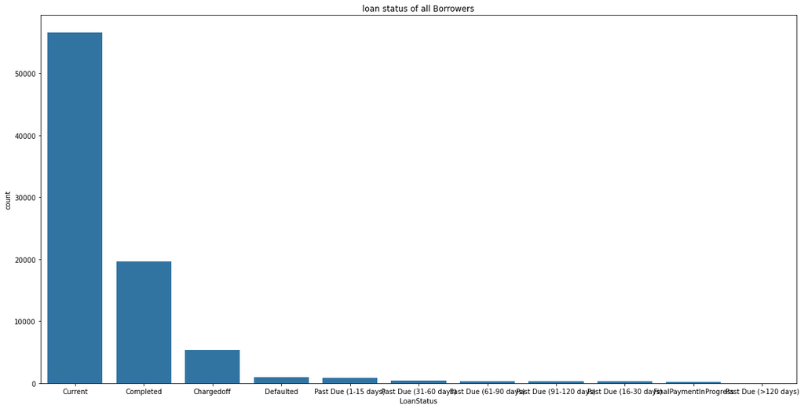

```python
plt.figure(figsize = [20, 10])
base_color = sb.color_palette()[0]
plt.title("loan status of all Borrowers")
sb.countplot(data = df2, x = 'LoanStatus', color = base_color,
             order = df2['LoanStatus'].value_counts().index);
```

#### most loan statues are current statues then the completed statues then the chargedoff then the others

### let's look at the number of borrowers who are Homes owners

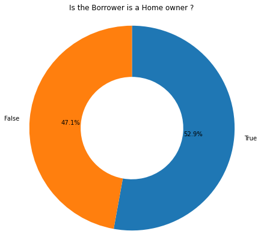

```python
plt.figure(figsize = [15, 7])
NDF = df2['IsBorrowerHomeowner'].value_counts()
plt.pie(NDF, labels = NDF.index, startangle = 90,
        counterclock = False, wedgeprops = {'width' : 0.5}, autopct   = '%.1f%%');
plt.title("Is the Borrower is a Home owner ?")
plt.axis('square');
```

#### The number of Borrowers who are Homes owners is sligtly more than the number of Borrower who are not Homes owners

### Let's look at the category of the listing that the borrower selected when posting their listing

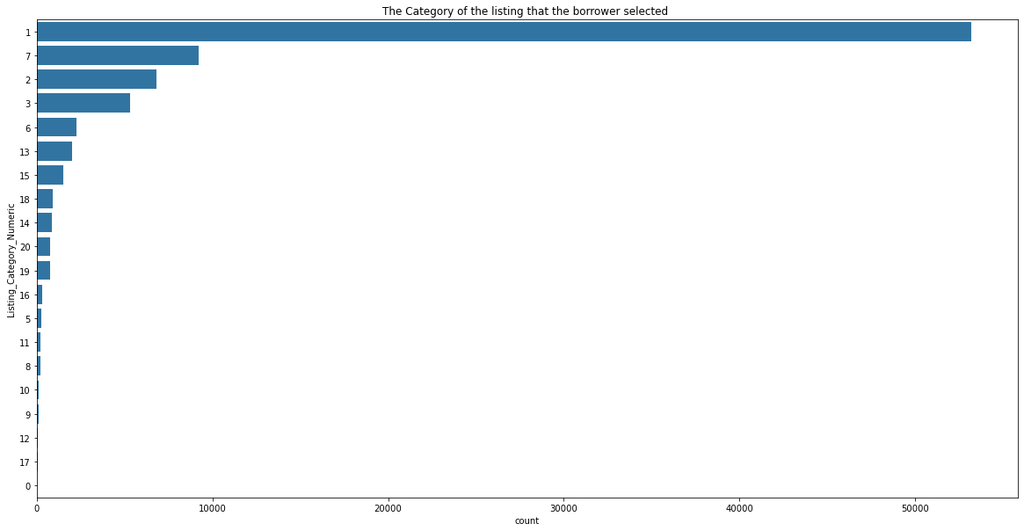

```python
plt.figure(figsize = [20, 10])
base_color = sb.color_palette()[0]
plt.title("The Category of the listing that the borrower selected ")
sb.countplot(data = df2, y = 'Listing_Category_Numeric', color = base_color,
             order = df2['Listing_Category_Numeric'].value_counts().index );
```

#### Most borrowers take the loan for Debt Consolidation

### Let's look at the Employment Status of all Borrowers

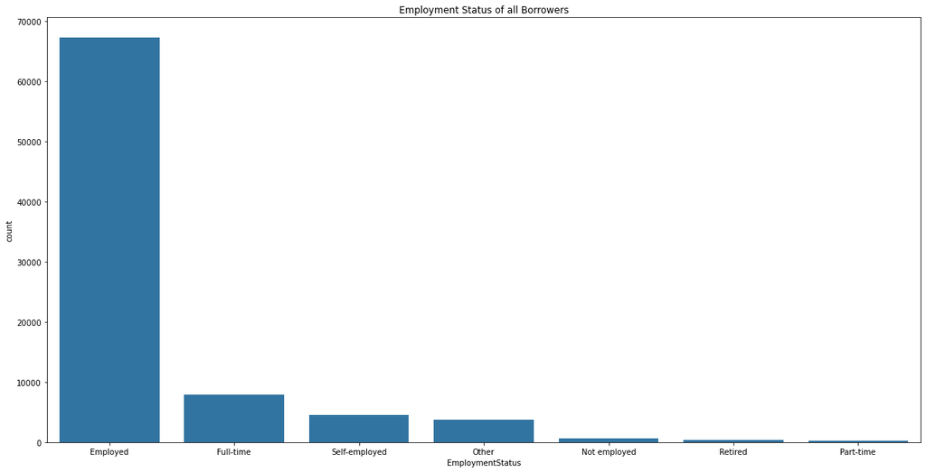

```python
plt.figure(figsize = [20, 10])
base_color = sb.color_palette()[0]
plt.title("Employment Status of all Borrowers")
sb.countplot(data = df2, x = 'EmploymentStatus', color = base_color,
             order = df2['EmploymentStatus'].value_counts().index);
```

### Let's look at the ranges of the income for all the borrowers

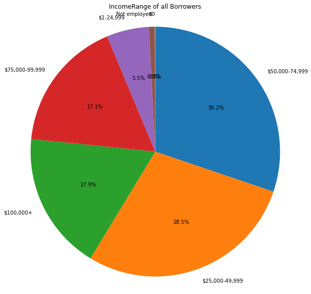

```python
plt.figure(figsize = [20, 10])
sorted_counts = df2['IncomeRange'].value_counts()
plt.pie(sorted_counts, labels = sorted_counts.index, startangle = 90,
        counterclock = False, autopct   = '%.1f%%');
plt.title("IncomeRange of all Borrowers")
plt.axis('square');
```

#### Most Borrowers have an income range 50000 - 74999 $

### let's look at the Term counts

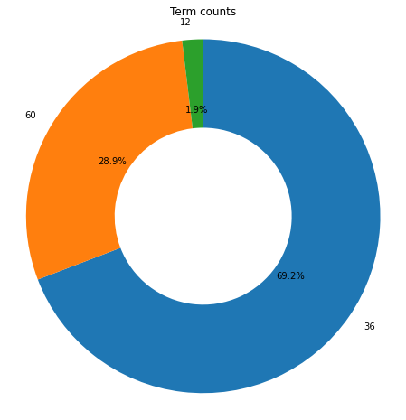

```python
plt.figure(figsize = [15, 8])
NDF = df2['Term'].value_counts()
plt.pie(NDF, labels = NDF.index, startangle = 90,
        counterclock = False, wedgeprops = {'width' : 0.5}, autopct   = '%.1f%%');
plt.title("Term counts")
plt.axis('square');
```

#### most of borrwers take the loan with term 36 monthes and the least of them take it with term 12 monthes

## The Insights of categorical variables analysis :

> most loan statues are current statues then the completed statues then the chargedoff then the others

> The number of Borrowers who are Homes owners is sligtly more than the number of Borrower who are not Homes owners

> Most borrowers take the loan for Debt Consolidation

> Most Borrowers have an income range 50000 - 74999 USD

> most of borrwers take the loan with term 36 monthes and the least of them take it with term 12 monthes

## Now we will start to Analyze the numeric attributes

##### the numeric variables names

```python
Numeric_df.columns
```

```
Index(['BorrowerAPR', 'BorrowerRate', 'Listing_Category_Numeric',
       'StatedMonthlyIncome', 'LoanOriginalAmount', 'PercentFunded',
       'Investors', 'MonthlyLoanPayment'],
      dtype='object')
```

### Let's look at the number of investors that funded the loan.

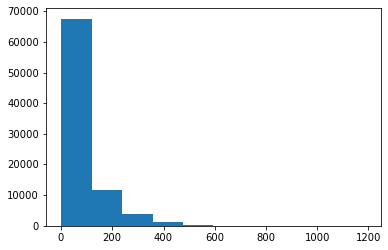

```python
plt.hist(data = df2, x = 'Investors');
```

```python
df2.Investors.min(), df2.Investors.max()
```

```
(1, 1189)
```

#### we should make log transformation

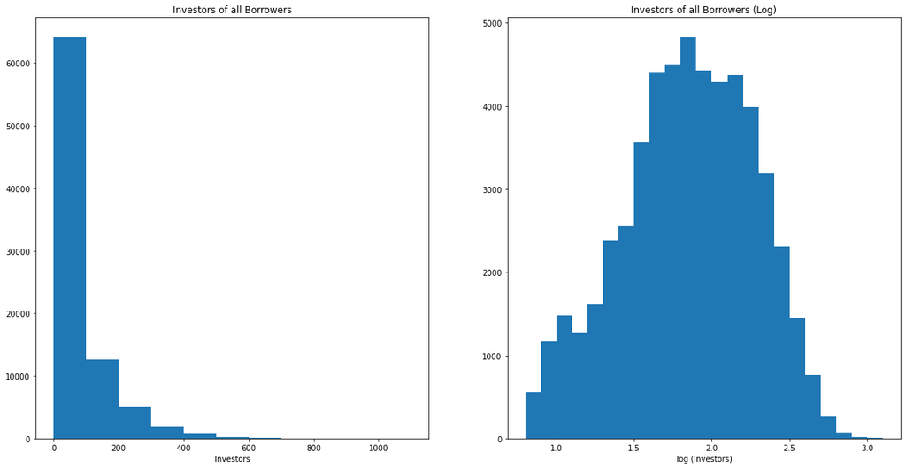

```python
plt.figure(figsize = [20, 10])

# left histogram: data plotted in natural units
plt.subplot(1, 2, 1)
bin_edges = np.arange(0, df2.Investors.max()+10, 100)
plt.hist(data =df2, x = 'Investors', bins = bin_edges)
plt.xlabel('Investors')
plt.title("Investors of all Borrowers");

# right histogram: data plotted after direct log transformation
plt.subplot(1, 2, 2)
log_data = np.log10(df2.Investors)
log_bin_edges = np.arange(0.8, log_data.max()+0.1, 0.1)
plt.hist(log_data, bins = log_bin_edges)
plt.xlabel('log (Investors)')
plt.title("Investors of all Borrowers (Log)");

df2.Investors_log = np.log10(df2.Investors)
```

#### most loans have number of investors that funded the loan between 0 and 100 investors

### Let's look at the borrower's interest rate for the loan

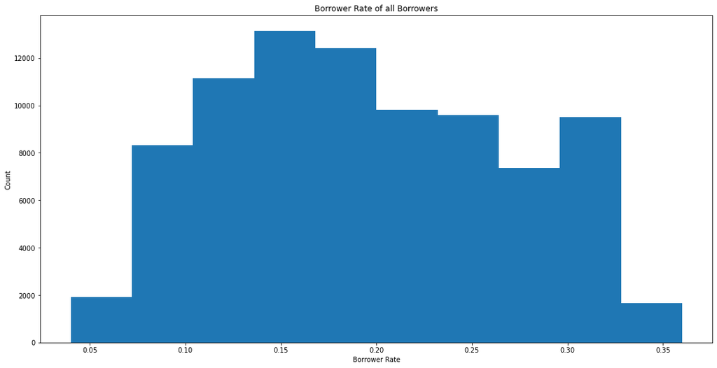

```python
plt.figure(figsize = [18, 9])
plt.hist(data = df2, x = 'BorrowerRate');
plt.xlabel('Borrower Rate');
plt.ylabel('Count');
plt.title("Borrower Rate of all Borrowers");
```

#### The most borrowers rate is 0.15

### Let's look at the Percent the listing was funded.

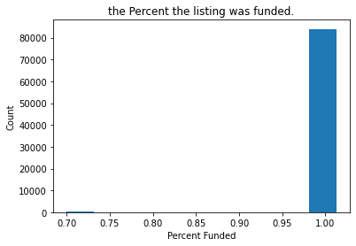

```python
plt.hist(data = df2, x = 'PercentFunded');
plt.xlabel('Percent Funded');
plt.ylabel('Count');
plt.title("the Percent the listing was funded.");
```

```python
df2.PercentFunded.describe()
```

```
count    84853.000000
mean         0.998098
std          0.020742
min          0.700000
25%          1.000000
50%          1.000000
75%          1.000000
max          1.012500
Name: PercentFunded, dtype: float64
```

#### most of percent funded is about 1 (100%)

### Let's look at the Borrower's Annual Percentage Rate (APR) for the loan.

```python
df2.BorrowerAPR.unique()
```

```
array([0.12016, 0.12528, 0.24614, ..., 0.28979, 0.23794, 0.22674])
```

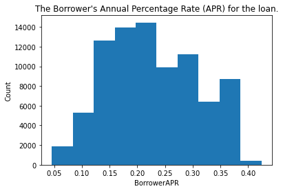

```python
plt.hist(data = df2, x = 'BorrowerAPR');
plt.xlabel('BorrowerAPR');
plt.ylabel('Count');
plt.title("The Borrower's Annual Percentage Rate (APR) for the loan.");
```

### Let's look at the monthly income the borrower stated at the time the listing was created.

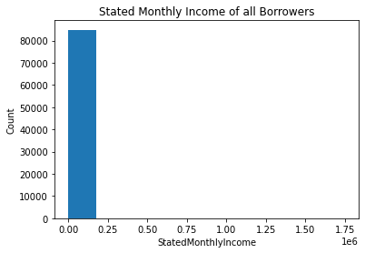

```python
plt.hist(data = df2, x = 'StatedMonthlyIncome');
plt.xlabel('StatedMonthlyIncome');
plt.ylabel('Count');
plt.title("Stated Monthly Income of all Borrowers");
```

look at the min and max values of Stated Monthly Income

```python
df2.StatedMonthlyIncome.describe()
```

```
count    8.485300e+04
mean     5.931175e+03
std      8.239944e+03
min      0.000000e+00
25%      3.434000e+03
50%      5.000000e+03
75%      7.083333e+03
max      1.750003e+06
Name: StatedMonthlyIncome, dtype: float64
```

```python
np.log10(df2.StatedMonthlyIncome.describe())
```

```
count    4.928667
mean     3.773141
std      3.915924
min          -inf
25%      3.535800
50%      3.698970
75%      3.850238
max      6.243039
Name: StatedMonthlyIncome, dtype: float64
```

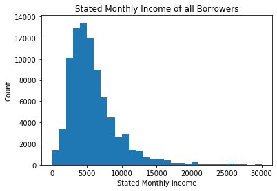

```python
df_sub = df2[df2['StatedMonthlyIncome'] <= 30000]
bin_edges = np.arange(0, df_sub['StatedMonthlyIncome'].max()+1000, 1000)
plt.hist(data = df2, x = 'StatedMonthlyIncome', bins = bin_edges);
plt.xlabel('Stated Monthly Income');
plt.ylabel('Count');
plt.title("Stated Monthly Income of all Borrowers");
```

#### Most of borrowers have a Monthly Income about 5000 $

### Let's look at the Loan Original Amount of all Borrowers

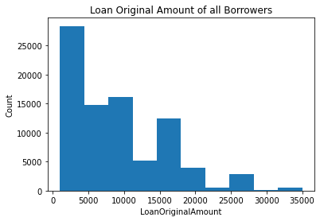

```python
plt.hist(data = df2, x = 'LoanOriginalAmount');
plt.xlabel('LoanOriginalAmount');
plt.ylabel('Count');
plt.title("Loan Original Amount of all Borrowers");
```

the histgram is right skewed

```python
df2['LoanOriginalAmount'].describe()
```

```
count    84853.000000
mean      9083.440515
std       6287.860058
min       1000.000000
25%       4000.000000
50%       7500.000000
75%      13500.000000
max      35000.000000
Name: LoanOriginalAmount, dtype: float64
```

```python
np.log10(df2['LoanOriginalAmount'].describe())
```

```
count    4.928667
mean     3.958250
std      3.798503
min      3.000000
25%      3.602060
50%      3.875061
75%      4.130334
max      4.544068
Name: LoanOriginalAmount, dtype: float64
```

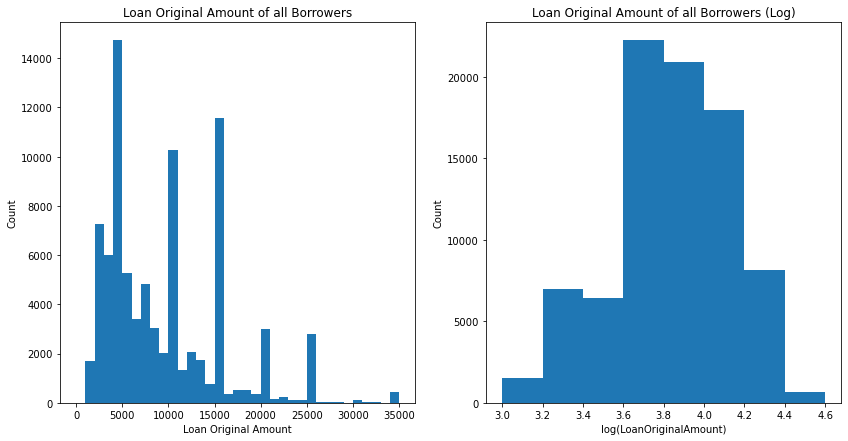

```python
plt.figure(figsize = [14, 7])

# left histogram: data plotted in natural units
plt.subplot(1, 2, 1)
bin_edges = np.arange(0, df2.LoanOriginalAmount.max()+1000, 1000)
plt.hist(data =df2, x = 'LoanOriginalAmount', bins = bin_edges)
plt.xlabel('Loan Original Amount')
plt.ylabel('Count');
plt.title("Loan Original Amount of all Borrowers");

# right histogram: data plotted after direct log transformation
plt.subplot(1, 2, 2)
log_data = np.log10(df2.LoanOriginalAmount)
log_bin_edges = np.arange(3.0, log_data.max()+0.1, 0.2)
plt.hist(log_data, bins = log_bin_edges)
plt.xlabel('log(LoanOriginalAmount)');
plt.ylabel('Count');
plt.title("Loan Original Amount of all Borrowers (Log)");

df2.LoanOriginalAmount_log = np.log10(df2.LoanOriginalAmount)
```

#### Loan Original Amount started from 1000 to 35000 and there are multiple peaks observed at 4000 , 10000 and 15000 $.

### Let's look at the monthly loan payment for all borrowers

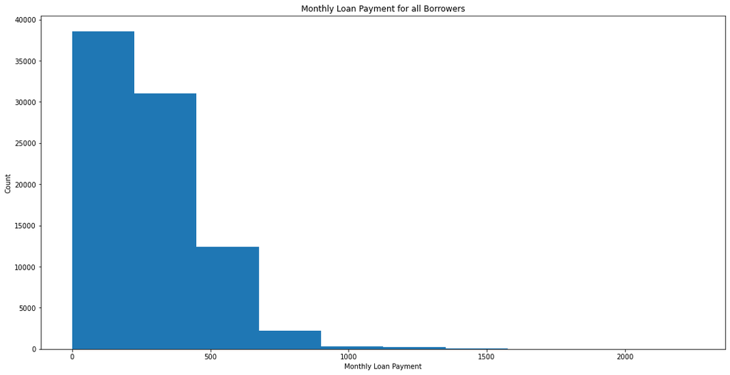

```python
plt.figure(figsize = [18, 9])
plt.hist(data = df2, x = 'MonthlyLoanPayment');
plt.xlabel('Monthly Loan Payment');
plt.ylabel('Count');
plt.title("Monthly Loan Payment for all Borrowers");
```

#### Most of borrowers pay less than 500 USD monthly for the loan

### Discuss the distribution(s) of your variable(s) of interest. Were there any unusual points? Did you need to perform any transformations?

> i need to make transformations for the variables (Investors , LoanOriginalAmount)

### Of the features you investigated, were there any unusual distributions? Did you perform any operations on the data to tidy, adjust, or change the form of the data? If so, why did you do this?

> changed the columns names that contain a white space to can work on them

> changed the data type of the Term variable to be category instead of int64

> drop all rows that contain NULL values

## The Insights of Numeric variables analysis :

> most loans have number of investors that funded the loan between 0 and 100 investors

> The most borrowers rate is 0.15

> most of percent funded is about 1 (100%)

> Most of borrowers have a Monthly Income about 5000 USD

> Loan Original Amount started from 1000 to 35000 and there are multiple peaks observed at 4000 , 10000 and 15000 USD

> Most of borrowers pay less than 500 USD monthly for the loan

## Bivariate Exploration

> In this section, investigate relationships between pairs of variables in your data. Make sure the variables that you cover here have been introduced in some fashion in the previous section (univariate exploration).

## Categorical Vs Numeric

### Check if the IncomeRange will affect on the borrower’s APR or not

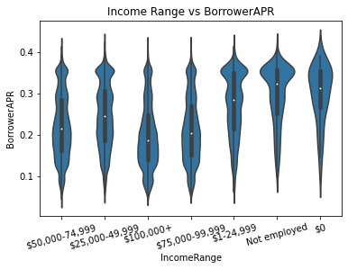

```python
base_color = sb.color_palette()[0]
sb.violinplot(data = df2, x = 'IncomeRange', y = 'BorrowerAPR', color = base_color)
plt.xticks(rotation = 15);
plt.title('Income Range vs BorrowerAPR')
```

### Check if the Term will affect on the borrower’s APR or not

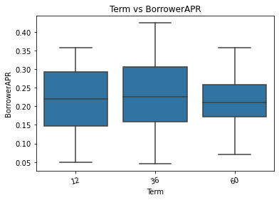

```python
base_color = sb.color_palette()[0]
sb.boxplot(data = df2, x = 'Term', y = 'BorrowerAPR', color = base_color)
plt.xticks(rotation = 15);
plt.title('Term vs BorrowerAPR')
```

#### (Not clear) we need another variable with these two variables but the APR don't affect directly by the Term

## Numeric Vs Numeric

### Check if the LoanOriginalAmount will affect on the borrower’s APR or not

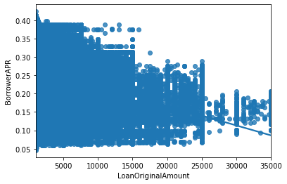

```python
sb.regplot(data = df2, x = 'LoanOriginalAmount', y = 'BorrowerAPR')
```

#### There is a correlation between the LoanOriginalAmount and the BorrowerAPR that the more LoanOriginalAmount the less of BorrowerAPR

### Check if the MonthlyLoanPayment will affect on the borrower’s APR or not

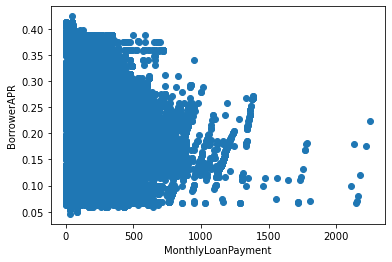

```python
plt.scatter(data = df2, x = 'MonthlyLoanPayment', y = 'BorrowerAPR')
plt.xlabel('MonthlyLoanPayment')
plt.ylabel('BorrowerAPR');
```

#### There is a correlation between the MonthlyLoanPayment and the BorrowerAPR that the less MonthlyLoanPayment the more of BorrowerAPR

### Talk about some of the relationships you observed in this part of the investigation. How did the feature(s) of interest vary with other features in the dataset?

> There is a correlation between the (MonthlyLoanPayment , LoanOriginalAmount , IncomeRange) and the BorrowerAPR

### Did you observe any interesting relationships between the other features (not the main feature(s) of interest)?

> No

## The Insights of Bivariate Exploration :

> There is a correlation between the LoanOriginalAmount and the BorrowerAPR that the more LoanOriginalAmount the less of BorrowerAPR

> There is a correlation between the MonthlyLoanPayment and the BorrowerAPR that the less MonthlyLoanPayment the more of BorrowerAPR

## Multivariate Exploration

> Create plots of three or more variables to investigate your data even further. Make sure that your investigations are justified, and follow from your work in the previous sections.

### Check if the borrowers who are home owners impacted the Borrower Interest Rate and ProsperRating

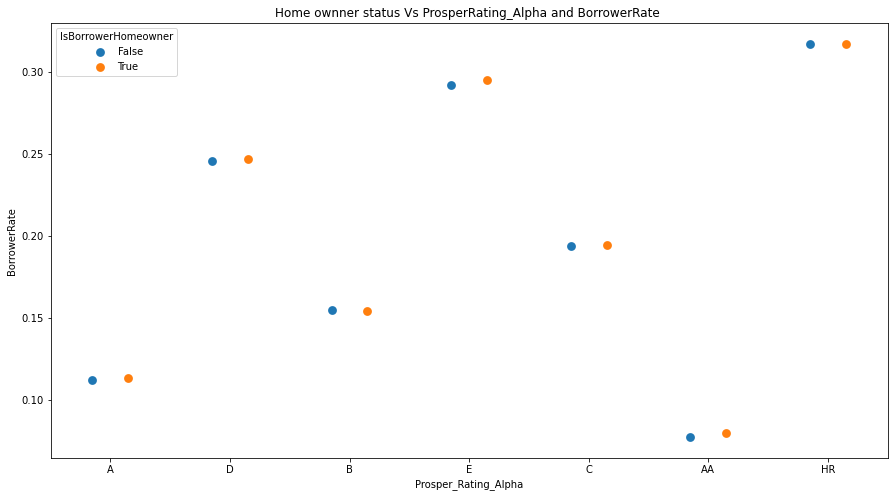

```python
plt.figure(figsize = [15, 8])
sb.pointplot(data = df2, x = 'Prosper_Rating_Alpha', y = 'BorrowerRate', hue = 'IsBorrowerHomeowner',
                  dodge = 0.3, linestyles = "");
plt.title('Home ownner status Vs ProsperRating_Alpha and BorrowerRate ');
```

### Check if the Term affect on the IncomeRange and BorrowerAPR

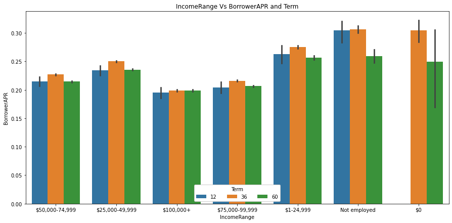

```python
plt.figure(figsize = [15, 7])

ax = sb.barplot(data = df2, x = 'IncomeRange', y = 'BorrowerAPR', hue = 'Term')
ax.legend(loc = 8, ncol = 3, framealpha = 1, title = 'Term')
plt.title('IncomeRange Vs BorrowerAPR and Term');
```

#### The term (36 monthes) have a biggest APR for all of borrowers who have an income range less than 100000 $

### Talk about some of the relationships you observed in this part of the investigation. Were there features that strengthened each other in terms of looking at your feature(s) of interest?

> The term (36 monthes) have a biggest APR for all of borrowers who have an income range less than 100000 USD